# Lab01 - Introduction to PyTorch (Solution)

Tensor (`torch.tensor`) is the data structure used in PyTorch to build a deep learning system. Tensors are similar to NumPy's `ndarrays`, with the addition being that Tensors can also be used on a GPU to accelerate computing.

### Objectives:

In this lab, you learn how to

- Create tensors in PyTorch
- Perform mathematical operation on tensors
- Convert between PyTorch tensor and Numpy array
- Reshape a PyTorch tensor
- Transfer tensor to and from GPU

#### Table of Content:

1. Creating tensors
2. Tensor operations
3. Indexing
4. Reshaping tensors
5. CUDA Tensors
6. Exercise

#### Reference:

- [PyTorch Official Tutorial: What is PyTorch](https://pytorch.org/tutorials/beginner/blitz/tensor_tutorial.html#sphx-glr-beginner-blitz-tensor-tutorial-py)

```python
import torch
```

## 1. Creating tensors

Create with some predefined value and the data type is `torch.float32`.

```python
x = torch.tensor(((1., 2., 3.),
                  (4., 5., 6.)))
print(x)
print(x.dtype)
```

```
tensor([[1., 2., 3.],
        [4., 5., 6.]])
torch.float32
```

Create with some predefined value and the data type is `torch.int64`.

```python
x = torch.tensor(((1, 2, 3),
                  (4, 5, 6)))
print(x)
print(x.dtype)
```

```
tensor([[1, 2, 3],
        [4, 5, 6]])
torch.int64
```

Construct a matrix filled with zeros and explicitly specify the data type as int32

```python
x = torch.zeros(5, 3, dtype=torch.int32)
print(x)
```

```
tensor([[0, 0, 0],
        [0, 0, 0],
        [0, 0, 0],
        [0, 0, 0],
        [0, 0, 0]], dtype=torch.int32)
```

Construct a matrix filled with ones and of dtype float64

```python
x = torch.ones(5,3, dtype=torch.float64)
print(x)
```

```
tensor([[1., 1., 1.],
        [1., 1., 1.],
        [1., 1., 1.],
        [1., 1., 1.],
        [1., 1., 1.]], dtype=torch.float64)
```

Construct a tensor filled with random numbers from a uniform distribution on the interval `[0, 1)`.

```python
x = torch.rand(5, 3)
print(x)
```

```
tensor([[0.7873, 0.4808, 0.3222],
        [0.4522, 0.7706, 0.6131],
        [0.3157, 0.3424, 0.6883],
        [0.5145, 0.7258, 0.6024],
        [0.7020, 0.7176, 0.9362]])
```

Construct a tensor filled with random numbers from a normal distribution with mean 0 and variance 1.

```python
x = torch.randn(5, 3)
print(x)
```

```
tensor([[-2.4187,  0.5921,  1.4036],
        [ 0.6735, -0.4761, -0.1762],
        [-0.9525, -0.1749,  1.2646],
        [-0.8105, -1.2901,  0.7616],
        [-0.5273, -0.2157,  0.6559]])
```

Construct a tensor filled with integers ranging from 0 to 9 with a shape of (5, 3). The 1st argument is the starting index (inclusive), the 2nd argument is the ending index (exclusive), and the third argument is a tuple specifying the targeted shape.

```python
x = torch.randint(0, 10, (5, 3))
print(x)
```

```
tensor([[2, 6, 5],
        [5, 4, 0],
        [5, 4, 5],
        [3, 6, 4],
        [8, 3, 3]])
```

## 2. Tensor Operations

#### Size of tensors

You can print the shape of tensors by either using the attribute `.shape` or the function `.size()`.

```python
x = torch.rand(5, 3)
print('x:\n', x)
print('Shape of x:', x.size())
print('Shape of x:', x.shape)
```

```
x:
 tensor([[0.4825, 0.6908, 0.4039],
        [0.5943, 0.4005, 0.5113],
        [0.6331, 0.7803, 0.8240],
        [0.8437, 0.6066, 0.5387],
        [0.1443, 0.7389, 0.4057]])
Shape of x: torch.Size([5, 3])
Shape of x: torch.Size([5, 3])
```

#### Element-wise operations

In PyTorch, many operations, e.g., `*`, `+`, `/`, `torch.exp`, `torch.log`, etc., are basically element-wise operations of two arrays with the **same** shape. E.g., element-wise multiplication multiplies the items at the corresponding location.

The following shows different ways of performing multiplication

```python
a = torch.randint(0, 10, (5,))
print('a:\n', a)

b = torch.randint(0, 10, (5,))
print('b:\n', b)
print('---------------------------')

### --- the * operator  ---
out = a * b
print('a * b:\n', out)

### --- torch.multiply ---
out = torch.multiply(a, b)
print('\ntorch.multiply:\n', out)


### --- <tensor>.multiply ---
out = a.multiply(b)
print('\na.multiply(b):\n', out)


### --- inplace operations ---
b.multiply_(a)
print('\nInplace multiplication:')
print('a:', a)
print('b:', b)
```

```
a:
 tensor([4, 5, 2, 6, 2])
b:
 tensor([6, 6, 9, 7, 2])
---------------------------
a * b:
 tensor([24, 30, 18, 42,  4])

torch.multiply:
 tensor([24, 30, 18, 42,  4])

a.multiply(b):
 tensor([24, 30, 18, 42,  4])

Inplace multiplication:
a: tensor([4, 5, 2, 6, 2])
b: tensor([24, 30, 18, 42,  4])
```

Examples of other binary operations:

```python
a = torch.randint(1, 10, (5,))
print('a:\n', a)

b = torch.randint(1, 10, (5,))
print('b:\n', b)
print('-------------------------')

# --- addition ---
out = a + b
print('a + b:\n', out)

# --- subtraction ---
out = a - b
print('a - b:\n', out)

# --- multiplication ---
out = a * b
print('a * b:\n', out)

# --- division ---
out = a / b
print('a / b:\n', out)

# --- floor division ---
out = a // b
print('a // b:\n', out)

# --- power ---
out = a**b
print('a ^ b:\n', out)

# --- modulus ---
out = a%b
print('a % b:\n', out)
```

```
a:
 tensor([8, 5, 6, 5, 2])
b:
 tensor([7, 2, 1, 6, 9])
-------------------------
a + b:
 tensor([15,  7,  7, 11, 11])
a - b:
 tensor([ 1,  3,  5, -1, -7])
a * b:
 tensor([56, 10,  6, 30, 18])
a / b:
 tensor([1.1429, 2.5000, 6.0000, 0.8333, 0.2222])
a // b:
 tensor([1, 2, 6, 0, 0])
a ^ b:
 tensor([2097152,      25,       6,   15625,     512])
a % b:
 tensor([1, 1, 0, 5, 2])
```

Examples of unary operations:

```python
a = torch.rand(2, 3)
print('a:\n', a)
print('-----------------------------------------')

# --- exponent ---
out = a.exp()
print('exponent of a:\n', out)

# --- ln ---
out = a.log()
print('\nln of a:\n', out)

# --- log base 10 ---
out = a.log10()
print('\nlog base 10 of a:\n', out)

# --- sum ---
out = a.sum()
print('\nsum of a:', out)

# --- mean ---
out = a.mean()
print('\nmean of a:', out)

# --- mean ---
out = a.max()
print('\nmax of a:', out)

# --- min ---
out = a.min()
print('\nmin of a:', out)
```

```
a:
 tensor([[0.5324, 0.2650, 0.5765],
        [0.9344, 0.6316, 0.9229]])
-----------------------------------------
exponent of a:
 tensor([[1.7030, 1.3034, 1.7797],
        [2.5457, 1.8806, 2.5166]])

ln of a:
 tensor([[-0.6303, -1.3281, -0.5508],
        [-0.0678, -0.4595, -0.0802]])

log base 10 of a:
 tensor([[-0.2737, -0.5768, -0.2392],
        [-0.0295, -0.1996, -0.0348]])

sum of a: tensor(3.8628)

mean of a: tensor(0.6438)

max of a: tensor(0.9344)

min of a: tensor(0.2650)
```

For `sum`, `mean`, `max` and `min` operations, we can perform the operation on a particular dimension rather than on the whole tensor.

```python
a = torch.randn(2, 3)
print('a:\n', a)
print('-----------------------------------------')

values, indices = a.max(dim=1)
print('\nMax value in each row:', values)
print('Indices of the max value in each row:', indices)

values, indices = a.max(dim=0)
print('\nMax value in each col:', values)
print('Indices of max value in each col:', indices)
```

```
a:
 tensor([[-0.7965, -0.1490, -1.0979],
        [ 1.1394,  2.0014, -0.3642]])
-----------------------------------------

Max value in each row: tensor([-0.1490,  2.0014])
Indices of the max value in each row: tensor([1, 1])

Max value in each col: tensor([ 1.1394,  2.0014, -0.3642])
Indices of max value in each col: tensor([1, 1, 1])
```

#### Broadcasting

Boadcasting allows element-wise operations on tensors that are not of the same size. Pytorch automatically broadcast the *smaller* tensor to the size of the *larger* tensor, if certain constraints are met.

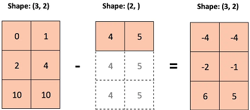

```python
a = torch.randint(0, 10, (3, 2))
print('a:\n', a)

b = torch.randint(0, 10, (2,))
print('b:\n', b)

c = a - b
print('\na - b:\n', c)
```

```
a:
 tensor([[5, 5],
        [1, 9],
        [9, 2]])
b:
 tensor([2, 1])

a - b:
 tensor([[ 3,  4],
        [-1,  8],
        [ 7,  1]])
```

The dimensions must be compatible for broadcasting to work. Here, since the 1st dimension of the two tensors are not the same, broadcasting cannot be performed.

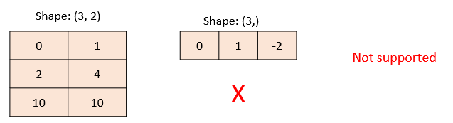

```python
a = torch.randint(0, 10, (3, 2))
print('a:\n', a)

b = torch.randint(0, 10, (3,))
print('b:\n', b)

c = a - b
print('\na - b:\n', c)
```

```
a:
 tensor([[8, 0],
        [4, 1],
        [1, 6]])
b:
 tensor([1, 0, 0])
```

```
---------------------------------------------------------------------------
RuntimeError                              Traceback (most recent call last)
Cell In[49], line 7
      4 b = torch.randint(0, 10, (3,))
      5 print('b:\n', b)
----> 7 c = a - b
      8 print('\na - b:\n', c)

RuntimeError: The size of tensor a (2) must match the size of tensor b (3) at non-singleton dimension 1
```

To overcome above problem, ensure that the two tensors have the same dimensions where the number of elements set for the dimensions targeted for broadcasting set to 1.

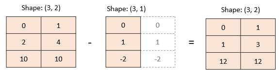

```python
a = torch.randint(0, 10, (3, 2))
print('a:\n', a)

b = torch.randint(0, 10, (3,1))
print('b:\n', b)

c = a - b
print('\na - b:\n', c)
```

```
a:
 tensor([[5, 2],
        [7, 6],
        [1, 3]])
b:
 tensor([[5],
        [7],
        [4]])

a - b:
 tensor([[ 0, -3],
        [ 0, -1],
        [-3, -1]])
```

#### Matrix operations

*Matrix operations* are different from *element-wise operation* where the former is based on the rules of linear algebra. Different from numpy, the `dot` command is used only to perform dot product (`dot`). To perform the tensor multiplication of tensors with different dimensions, use the command `matmul` or the `@` operator.

```python
vec1 = torch.randn(2, )
print('vec1', vec1)

vec2 = torch.randn(2, )
print('vec3', vec2)

mat1 = torch.randn(3, 2)
print('mat1', mat1)

mat2 = torch.randn(2, 4)
print('mat2', mat2)
```

```
vec1 tensor([ 1.3704, -0.8124])
vec3 tensor([-0.4686, -0.3271])
mat1 tensor([[ 0.9403,  0.7636],
        [-0.1613, -0.7987],
        [-1.5334, -0.4436]])
mat2 tensor([[-0.5215, -1.8774,  1.0223,  0.4543],
        [ 0.1978,  0.2512,  0.4312, -1.6411]])
```

**`dot`**

This function can only perform vector-vector multiplication in PyTorch.

```python
out = torch.dot(vec1, vec2)  # ok, dot can be used to perform dot product of two vectors
print('out =', out)
```

```
out = tensor(-0.3764)
```

```python
out = torch.dot(mat1, vec1)  # not ok, dot function cannot perform tensor multiplication.
print('out =', out)
```

```
---------------------------------------------------------------------------
RuntimeError                              Traceback (most recent call last)
Cell In[61], line 1
----> 1 out = torch.dot(mat1, vec1)  # not ok, dot function cannot perform tensor multiplication.
      2 print('out =', out)

RuntimeError: 1D tensors expected, but got 2D and 1D tensors
```

**`matmul`**

```python
out1 = torch.matmul(vec1, vec2)  # vector-vector multiplication (dot product)
print('out1\n', out1)

out2 = torch.matmul(mat1, vec1)  # matrix-vector multiplication
print('out2\n', out2)

out3 = torch.matmul(mat1, mat2)  # matrix-matrix multiplication
print('out3\n', out3)
```

```
out1
 tensor(-0.3764)
out2
 tensor([ 0.6683,  0.4277, -1.7411])
out3
 tensor([[-0.3393, -1.5734,  1.2905, -0.8260],
        [-0.0739,  0.1023, -0.5093,  1.2374],
        [ 0.7120,  2.7674, -1.7589,  0.0314]])
```

The `@` operator

```python
out1 = vec1 @ vec2    # vector-vector multiplication (dot product)
print('out1\n', out1)

out2 = mat1 @ vec1    # matrix-vector multiplication
print('out2\n', out2)

out3 = mat1 @ mat2    # matrix-matrix multiplication
print('out3\n', out3)
```

```
out1
 tensor(-0.3764)
out2
 tensor([ 0.6683,  0.4277, -1.7411])
out3
 tensor([[-0.3393, -1.5734,  1.2905, -0.8260],
        [-0.0739,  0.1023, -0.5093,  1.2374],
        [ 0.7120,  2.7674, -1.7589,  0.0314]])
```

## 3. Indexing

You can use standard Numpy-like indexing with Torch

```python
x = torch.randint(0, 100, (5,10))
print(x)
```

```
tensor([[67, 65, 20, 69, 69, 39, 34, 97, 15, 44],
        [91, 77,  0,  7, 81, 64, 91, 20, 41, 91],
        [75, 39, 74, 30, 33, 51, 59,  9, 13,  1],
        [66,  6, 41, 24, 70, 25, 94, 43, 25, 92],
        [74, 97, 61, 87, 60, 94, 26, 38,  7, 75]])
```

```python
# accessing column 1
print(x[:,1])
```

```
tensor([65, 77, 39,  6, 97])
```

```python
# accessing columns 2 and 3
print(x[:, 2:4])
```

```
tensor([[20, 69],
        [ 0,  7],
        [74, 30],
        [41, 24],
        [61, 87]])
```

```python
# accessing row 1
print(x[1,:])
```

```
tensor([91, 77,  0,  7, 81, 64, 91, 20, 41, 91])
```

```python
# accessing rows 2 and 3
print(x[2:4,:])
```

```
tensor([[75, 39, 74, 30, 33, 51, 59,  9, 13,  1],
        [66,  6, 41, 24, 70, 25, 94, 43, 25, 92]])
```

## 4. Reshaping Tensors

**`Tensor.reshape`**

Returns a tensor with the same data and number of elements as self but with the specified shape.

```python
x = torch.randn(2, 3)
print('x:\n', x)
```

```
x:
 tensor([[ 1.2501, -2.3318,  0.4920],
        [ 1.1427,  0.3921,  0.6333]])
```

```python
# reshape from (2, 3) to (6, 1)
y = x.reshape(6, 1)
print('y:\n', y)
```

```
y:
 tensor([[ 1.2501],
        [-2.3318],
        [ 0.4920],
        [ 1.1427],
        [ 0.3921],
        [ 0.6333]])
```

```python
# Reshape from (2, 3) to (3, 2)
z = x.reshape(3, 2)
print('z:\n', z)
```

```
z:
 tensor([[ 1.2501, -2.3318],
        [ 0.4920,  1.1427],
        [ 0.3921,  0.6333]])
```

### View vs Copy

This method returns a **view** if shape is compatible with the current shape. Else, it may return a **copy**. This allows it to work with both [contiguous and non-contigous](https://stackoverflow.com/questions/26998223/what-is-the-difference-between-contiguous-and-non-contiguous-arrays/26999092#26999092) data. But what is a view or a copy? The following section explains their difference

For example, reshaping on the input tensor directly `y = x.reshape(-1, 1)` returns a **view** of `x`. On the other hand, reshaping on the transpose of the input tensor `z = x.T.reshape(-1, 1)` returns a **copy** of `x`.

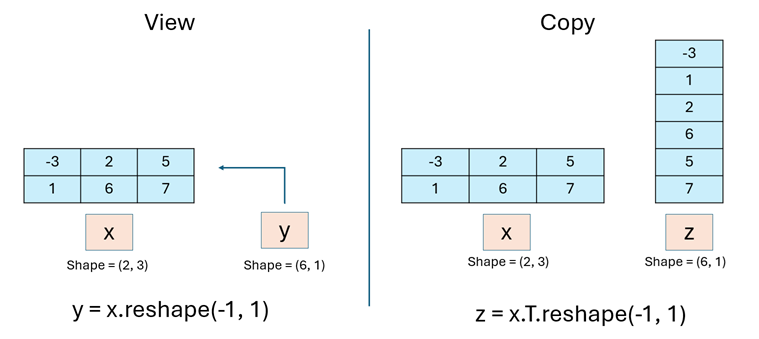

Reshaping on the input tensor directly `y = x.reshape(-1, 1)` returns a **view** of `x`. Therefore, changing `x` affects both `x` and `y`, and vice versa.

```python
x = torch.tensor(((-3, 2, 5), (1, 6, 7)))
y = x.reshape(-1, 1)

print('x:\n', x)
print('y:\n', y)
```

```
x:
 tensor([[-3,  2,  5],
        [ 1,  6,  7]])
y:
 tensor([[-3],
        [ 2],
        [ 5],
        [ 1],
        [ 6],
        [ 7]])
```

```python
is_view = x.untyped_storage().data_ptr() == y.untyped_storage().data_ptr()
print('x is a view of y:', is_view)
```

```
x is a view of y: True
```

```python
print('x:\n', x)
print('z:\n', y)

y[0] = -999

print('\n--- After modifying z ---')
print('x:\n', x)
print('y:\n', y)
```

```
x:
 tensor([[-3,  2,  5],
        [ 1,  6,  7]])
z:
 tensor([[-3],
        [ 2],
        [ 5],
        [ 1],
        [ 6],
        [ 7]])

--- After modifying z ---
x:
 tensor([[-999,    2,    5],
        [   1,    6,    7]])
y:
 tensor([[-999],
        [   2],
        [   5],
        [   1],
        [   6],
        [   7]])
```

Reshaping on the transpose of the input tensor `z = x.T.reshape(-1, 1)` returns a **copy** of `x`. Therefore, changing `x` does not affect `z`, and vice versa.

```python
x = torch.tensor(((-3, 2, 5), (1, 6, 7)))
z = x.T.reshape(-1, 1)

print('x:\n', x)
print('z:\n', z)
```

```
x:
 tensor([[-3,  2,  5],
        [ 1,  6,  7]])
z:
 tensor([[-3],
        [ 1],
        [ 2],
        [ 6],
        [ 5],
        [ 7]])
```

```python
is_view = x.untyped_storage().data_ptr() == z.untyped_storage().data_ptr()
print('x is a view of z:', is_view)
```

```
x is a view of z: False
```

```python
print('x:\n', x)
print('z:\n', z)

z[0] = -999

print('\n--- After modifying z ---')
print('x:\n', x)
print('z:\n', z)
```

```
x:
 tensor([[-3,  2,  5],
        [ 1,  6,  7]])
z:
 tensor([[-3],
        [ 1],
        [ 2],
        [ 6],
        [ 5],
        [ 7]])

--- After modifying z ---
x:
 tensor([[-3,  2,  5],
        [ 1,  6,  7]])
z:
 tensor([[-999],
        [   1],
        [   2],
        [   6],
        [   5],
        [   7]])
```

### `Tensor.view`

`Tensor.view` always returns a **view** of the original tensor with the new shape, i.e., it will share the underlying data with the original tensor.

```python
x = torch.randint(0, 100, (2, 4))
print('x:\n', x)
```

```
x:
 tensor([[14, 86,  8, 66],
        [51, 76, 86, 88]])
```

```python
# Convert from (2, 4) to (8, 1)
y = x.view(8, -1)
print('y:\n', y)
```

```
y:
 tensor([[14],
        [86],
        [ 8],
        [66],
        [51],
        [76],
        [86],
        [88]])
```

```python
# Convert from (2, 4) to (4, 2)
z = x.view(4, 2)
print('z:\n', z)
```

```
z:
 tensor([[14, 86],
        [ 8, 66],
        [51, 76],
        [86, 88]])
```

Similar to the numpy's `reshape` function, pytorch's `view` returns a reference of the original matrix albeit in a different shape

## 5. CUDA Tensors

#### Creating tensor in the GPU

```python
if torch.cuda.is_available():
    gpu = torch.device("cuda")  # define a cuda device
    x = torch.ones((2, 4), device = gpu) # Create the tensor in the GPU
    print(x)
```

```
tensor([[1., 1., 1., 1.],
        [1., 1., 1., 1.]], device='cuda:0')
```

#### Creating tensor in the cpu explicitly (default )

```python
cpu = torch.device("cpu")
x = torch.ones((2, 4), device = cpu)     # create a tensor in the CPU
print(x)
```

```
tensor([[1., 1., 1., 1.],
        [1., 1., 1., 1.]])
```

#### Transfering tensor from cpu to gpu

Transfer using the `.cuda()` command.

```python
x = torch.rand(3, 2, device = "cpu")  # create tensor in cpu. The device argument also accepts a string besides a device object
print(x)

x = x.cuda()  # move to GPU
print(x)
```

```
tensor([[0.8103, 0.5353],
        [0.2715, 0.1616],
        [0.8430, 0.4290]])
tensor([[0.8103, 0.5353],
        [0.2715, 0.1616],
        [0.8430, 0.4290]], device='cuda:0')
```

Transfer using the `.to()` command

```python
x = torch.rand(3, 2) # create tensor in the CPU (default)
print(x)

gpu = torch.device('cuda')  # move to GPU
x = x.to(gpu)
print(x)
```

```
tensor([[0.1850, 0.9743],
        [0.1770, 0.5666],
        [0.0052, 0.1209]])
tensor([[0.1850, 0.9743],
        [0.1770, 0.5666],
        [0.0052, 0.1209]], device='cuda:0')
```

#### Transfering tensor from gpu to cpu

Transfer using the `.cpu()` command.

```python
x = torch.rand(3, 2, device = 'cuda')  # create tensor in gpu. The device argument also accepts a string besides a device object
print(x)

x = x.cpu()  # move to CPU
print(x)
```

```
tensor([[0.5975, 0.7399],
        [0.9092, 0.7406],
        [0.1240, 0.5098]], device='cuda:0')
tensor([[0.5975, 0.7399],
        [0.9092, 0.7406],
        [0.1240, 0.5098]])
```

Transfer using the `.to()` command.

```python
x = torch.rand(3, 2, device = 'cuda')  # create tensor in the GPU
print(x)

device = torch.device('cpu')
x = x.to(device)  # move to CPU
print(x)
```

```
tensor([[0.2495, 0.3030],
        [0.1399, 0.4648],
        [0.2928, 0.2766]], device='cuda:0')
tensor([[0.2495, 0.3030],
        [0.1399, 0.4648],
        [0.2928, 0.2766]])
```

## Exercise

**Question 1.** The following code is used to preprocess a batch data for Logistic Regression.

1.1 Create a random tensor `X_ori` using the normal distribution of shape `(4, 16, 16, 3)`. The tensor represent `m=4` color image samples, each having a resolution of `(16, 16)`. Expected ans: `Shape of X_ori: torch.Size([4, 16, 16, 3])`

```python
X_ori = torch.randn(4, 16, 16, 3)
print('Shape of X_ori:', X_ori.shape)
```

```
Shape of X_ori: torch.Size([4, 16, 16, 3])
```

1.2 Reshape `X_ori` into a shape of `(4, 16*16*3)` = `(4, 768)` where each row represents a sample. Save the result as `X`.

````
Expected ans:
```
Shape of X: torch.Size([4, 768])
```
````

```python
X = X_ori.view(X_ori.shape[0], -1)
print('Shape of X:', X.shape)
```

```
Shape of X: torch.Size([4, 768])
```

1.3 Check if a GPU is available in the system. If yes, transfer the tensor `X` to the GPU. Then, verify if X has really been loaded into the GPU (`X.is_cuda`) .

Expected ans (if GPU is available):

[output not shown]

```python
device = "cuda" if torch.cuda.is_available() else "cpu"

X = X.to(device)
print("X is loaded to GPU:", x.is_cuda)
```

```
X is loaded to GPU: False
```

1.4 Generate a random weight tensor `W` of shape (768, 1) by sampling from a normal distribution. Create a scalar tensor for the bias `b` with value 0.

```python
W = torch.randn(768, 1).to(device)
b = torch.tensor(0.).to(device)

print(f'{W.shape =}')
print(f'{b =}')
```

```
W.shape =torch.Size([768, 1])
b =tensor(0., device='cuda:0')
```

1.5 Implement the logistic regression to predict the input X.

$$ \mathbf{z} = \mathbf{X}\mathbf{W} + \mathbf{b} $$$$ \hat{\mathbf{y}} = \frac{1}{1+e^\mathbf{-z}} $$

```python
z = X @ W + b
print(f'{z = }')

yhat = 1/(1 + torch.exp(-z))
print(f'{yhat = }')
```

```
z = tensor([[ 39.1146],
        [ 32.8930],
        [-27.0572],
        [ -9.2880]], device='cuda:0')
yhat = tensor([[1.0000e+00],
        [1.0000e+00],
        [1.7750e-12],
        [9.2518e-05]], device='cuda:0')
```

**Question 2.**

2.1 Create the tensor `A`. Ensure that the datatype for `A` is `float32`.

```
A = ((2, 3, 5, 6),
         (3, 2, 4, 1),
         (-1, -1, -1, -1),
         (5, 1, 10, 3),
         (-1, -1, -1, -1))
```

```python
A = torch.tensor(((2, 3, 5, 6),
         (3, 2, 4, 1),
         (-1, -1, -1, -1),
         (5, 1, 10, 3),
         (-1, -1, -1, -1)), dtype=torch.float32)
print(A)
```

```
tensor([[ 2.,  3.,  5.,  6.],
        [ 3.,  2.,  4.,  1.],
        [-1., -1., -1., -1.],
        [ 5.,  1., 10.,  3.],
        [-1., -1., -1., -1.]])
```

2.2 Extract rows 0, 1 and 3.

Expected answer:

```
tensor([[ 2.,  3.,  5.,  6.],
        [ 3.,  2.,  4.,  1.],
        [ 5.,  1., 10.,  3.]])
```

```python
A = A[[0, 1, 3]]
print(A)
```

```
tensor([[ 2.,  3.,  5.,  6.],
        [ 3.,  2.,  4.,  1.],
        [ 5.,  1., 10.,  3.]])
```

2.3 Compute the min and the max of the rows. Keep the dimensions.

Expected ans:

```
--- min of rows ---
 tensor([[2.],
        [1.],
        [1.]])

--- max of rows ---
 tensor([[ 6.],
        [ 4.],
        [10.]])
```

```python
min_vals, _ = A.min(dim=1, keepdims=True)
max_vals, _ = A.max(dim=1, keepdims=True)

print('--- min of rows ---\n', min_vals)
print('\n--- max of rows ---\n', max_vals)
```

```
--- min of rows ---
 tensor([[2.],
        [1.],
        [1.]])

--- max of rows ---
 tensor([[ 6.],
        [ 4.],
        [10.]])
```

2.4 Normalize each row $i$ with the following equation:

$$ A_{norm}[i] = \frac{A[i] - \min(A[i])}{\max(A[i]) - \min(A[i])} $$

Notes: you need to apply broadcasting for this operation.

Expected output:

```
tensor([[0.0000, 0.2500, 0.7500, 1.0000],
        [0.6667, 0.3333, 1.0000, 0.0000],
        [0.4444, 0.0000, 1.0000, 0.2222]])
```

```python
A_norm = (A - min_vals) / (max_vals - min_vals)
print(A_norm)
```

```
tensor([[0.0000, 0.2500, 0.7500, 1.0000],
        [0.6667, 0.3333, 1.0000, 0.0000],
        [0.4444, 0.0000, 1.0000, 0.2222]])
```

--- END OF LAB01 ---